# Analyse Varianz vom Effekt Rassenkombination vs Heterosis/Rekombination

Sophie Kunz

30 4 2020

# Hintergrund

Aus den Ergebnissen der Modellselektion hat sich rausgestellt, dass sowohl der fixen Effekt Rassenkombination wie auch Heterosis und Rekombination im Modell für alle Schlachtmerkmale enthalten sollten. Dieses Ergebnis ist unerwartet.

# Ziel

Analyse aus dem gesamten Datensatz von der Varianz der wichtigsten Effekte für Rassenkombination sowie Heterosis und Rekombination.

# Vorgehen

Der Merkmalsblock Schlachtgewicht wurde ausgewählt, da es ist der “sauberste” erhobene Merkmal. Dann wird von den 10 verbreitesten Rassenkombinationen die Varianz von

- Jeder Heterosis- sowie Rekombinationskoeffizient analysiert
- Der Summe von Heterosis- sowie Rekombinationskoeffizient analysiert
- Die Kodierung von Heterosis- sowie Rekombinationseffekt analysiert

# Analyse

```
## # A tibble: 10 x 3
## # Groups:   breedcomb, SxD [10]
##    breedcomb SxD        n
##        <dbl> <chr>  <int>
##  1         4 BV.BV 138694
##  2         1 LM.BV  74443
##  3        15 HO.HO  50063
##  4        16 LM.KR  34322
##  5        23 LM.HO  23617
##  6         9 SI.SI  21000
##  7        26 UF.BV  16147
##  8         8 LM.SF  11659
##  9        19 AN.AN  11013
## 10        10 LM.SI  10563
```

```r
# number Grossviehmast
tbl_daten %>% filter(cwao != 0) %>% tally()
```

```
## # A tibble: 1 x 1
##        n
##    <int>
## 1 102941
```

```r
# number Natura-Beef
tbl_daten %>% filter(cwan != 0) %>% tally()
```

```
## # A tibble: 1 x 1
##       n
##   <int>
## 1 48835
```

```r
# number SwissPrimBeef&Natura-Farm
tbl_daten %>% filter(cwas != 0) %>% tally()
```

```
## # A tibble: 1 x 1
##       n
##   <int>
## 1  8773
```

```r
# number Kälbermast
tbl_daten %>% filter(cwco != 0) %>% tally()
```

```
## # A tibble: 1 x 1
##        n
##    <int>
## 1 228115
```

```r
# number Natura-Veal
tbl_daten %>% filter(cwcn != 0) %>% tally()
```

```
## # A tibble: 1 x 1
##       n
##   <int>
## 1  2857
```

Es wird erstmal auf dem Merkmal `cwao` (also Schlachtgewicht Grossviehmast) fokussiert.

## breedcomb LM.BV

Es wird zu dem spezifischen Heterosiskoeffizient von LM.BV angeschaut.

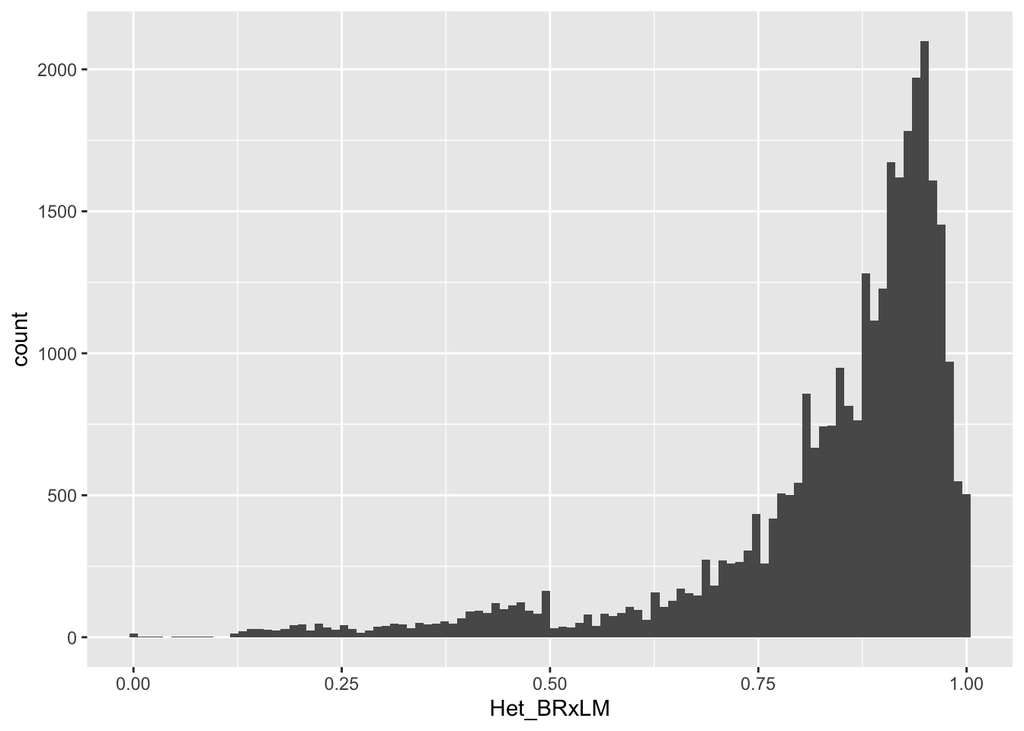

Es wird zu dem spezifischen Rekombinationskoeffizient von LM.BV angeschaut.

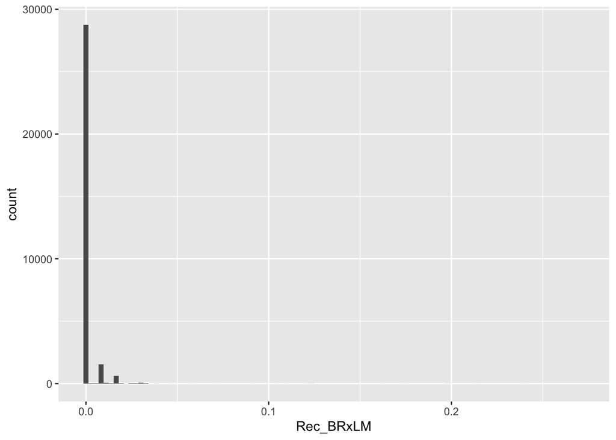

Es zu berücksichtigen in der Berechnung von Heterosis sowie Rekombination stützt sich auf Blutanteile. Es wird mit Gruppen gearbeiten. Dabei BV und BS ist in der Gruppe BR. Dafür OB und ROB in der Gruppe DP. Darunter einen Fall-Beispiel:

```
## # A tibble: 1 x 9
##   ind   Het_DPxLM Rec_DPxLM Het_DPxBR Rec_DPxBR Het_BRxLM Rec_BRxLM SumHet
##   <chr>     <dbl>     <dbl>     <dbl>     <dbl>     <dbl>     <dbl>  <dbl>
## 1 CH12…     0.297         0         0     0.209     0.703         0      1
## # … with 1 more variable: SumRec <dbl>
```

Es wird zu dem gesamten Heterosiskoeffizient von LM.BV angeschaut.

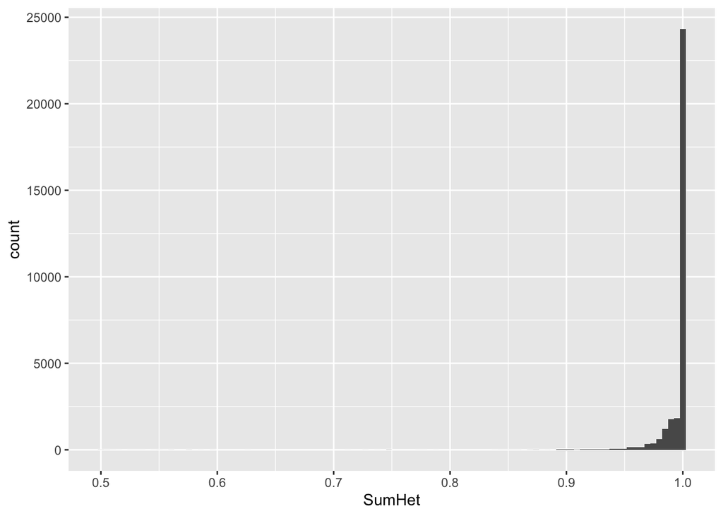

Es wird zu dem gesamten Rekombinationskoeffizient von LM.BV angeschaut.

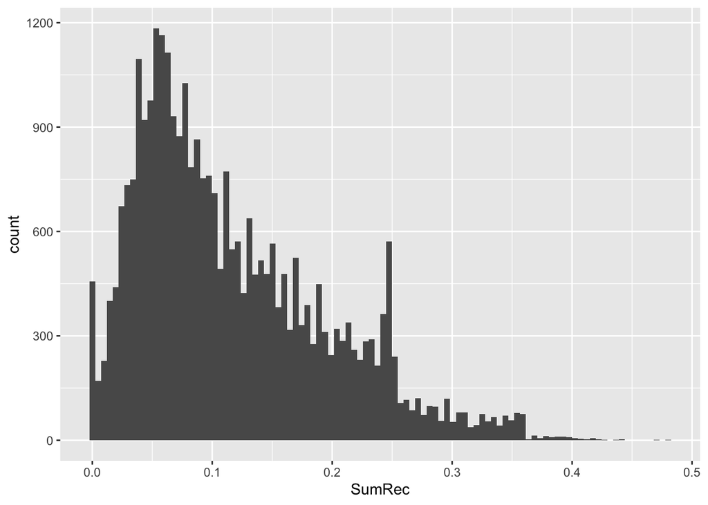

Mit dem gesamten Heterosis wird der Effekt dafür kodiert. Die Varianz von dem wird angeschaut.

```
## # A tibble: 4 x 2
## # Groups:   Effekt_HeterosisSumHet [4]
##   Effekt_HeterosisSumHet     n
##                    <dbl> <int>
## 1                      7 31335
## 2                      1    41
## 3                      5    27
## 4                      6    16
```

```r
#Part of the code in codeEff_HetRec.f90
#! Heterosis / Heterozygotie codieren
#    if(rHet_SumHet(indcid14(ind))==0.0)then
#      iHet_SumHet_Code(i)=2
#    elseif(rHet_SumHet(indcid14(ind))>0.0 .AND. rHet_SumHet(indcid14(ind))<=0.2)then
#      iHet_SumHet_Code(i)=3
#    elseif(rHet_SumHet(indcid14(ind))>0.2 .AND. rHet_SumHet(indcid14(ind))<=0.4)then
#      iHet_SumHet_Code(i)=4
#    elseif(rHet_SumHet(indcid14(ind))>0.4 .AND. rHet_SumHet(indcid14(ind))<=0.6)then
#      iHet_SumHet_Code(i)=5
#    elseif(rHet_SumHet(indcid14(ind))>0.6 .AND. rHet_SumHet(indcid14(ind))<=0.8)then
#      iHet_SumHet_Code(i)=6
#    elseif(rHet_SumHet(indcid14(ind))>0.8)then
#      iHet_SumHet_Code(i)=7
#    elseif(rHet_SumHet(indcid14(ind))==-9.99)then  ! Fuer das Tier konnte kein Heterosiseffektkoeffizient berechnet werden
#      iHet_SumHet_Code(i)=1
#    else
#      write(*,*)'FEHLER: Unbekannter Heterosiseffektkoeffizient SumHet in Zeile ',indcid14(ind),' von #',TRIM(cHetRecInFile),&
#               &' --> PROGRAMMABBRUCH'
#      call EXIT(iExitStatus)
#    endif
```

Mit dem gesamten Rekombination wird der Effekt dafür kodiert. Die Varianz von dem wird angeschaut.

```
## # A tibble: 7 x 2
## # Groups:   Effekt_RekombinationSumRec [7]
##   Effekt_RekombinationSumRec     n
##                        <dbl> <int>
## 1                          3 15910
## 2                          4  9757
## 3                          5  4369
## 4                          6   873
## 5                          2   438
## 6                          1    41
## 7                          7    31
```

```r
#Part of the code in codeEff_HetRec.f90
#! Rekombination codieren
#    if(rRec_SumRec(indcid14(ind))==0.0)then
#      iRec_SumRec_Code(i)=2
#    elseif(rRec_SumRec(indcid14(ind))>0.0 .AND. rRec_SumRec(indcid14(ind))<=0.1)then
#      iRec_SumRec_Code(i)=3
#    elseif(rRec_SumRec(indcid14(ind))>0.1 .AND. rRec_SumRec(indcid14(ind))<=0.2)then
#      iRec_SumRec_Code(i)=4
#    elseif(rRec_SumRec(indcid14(ind))>0.2 .AND. rRec_SumRec(indcid14(ind))<=0.3)then
#      iRec_SumRec_Code(i)=5
#    elseif(rRec_SumRec(indcid14(ind))>0.3 .AND. rRec_SumRec(indcid14(ind))<=0.4)then
#      iRec_SumRec_Code(i)=6
#    elseif(rRec_SumRec(indcid14(ind))>0.4)then
#      iRec_SumRec_Code(i)=7
#    elseif(rRec_SumRec(indcid14(ind))==-9.99)then  ! Fuer das Tier konnte kein Rekombinationseffektkoeffizient berechnet #werden
#      iRec_SumRec_Code(i)=1
#    else
#      write(*,*)'FEHLER: Unbekannter Rekombinationseffektkoeffizient SumRec in Zeile ',indcid14(ind),' von #',TRIM(cHetRecInFile),&
#               &' --> PROGRAMMABBRUCH'
#      call EXIT(iExitStatus)
#    endif
```

## breedcomb BV.BV

Da es kein spezifischen Heterosiskoeffizient für BV.BV, es wird direkt dem gesamten Heterosiskoeffizient angeschaut.

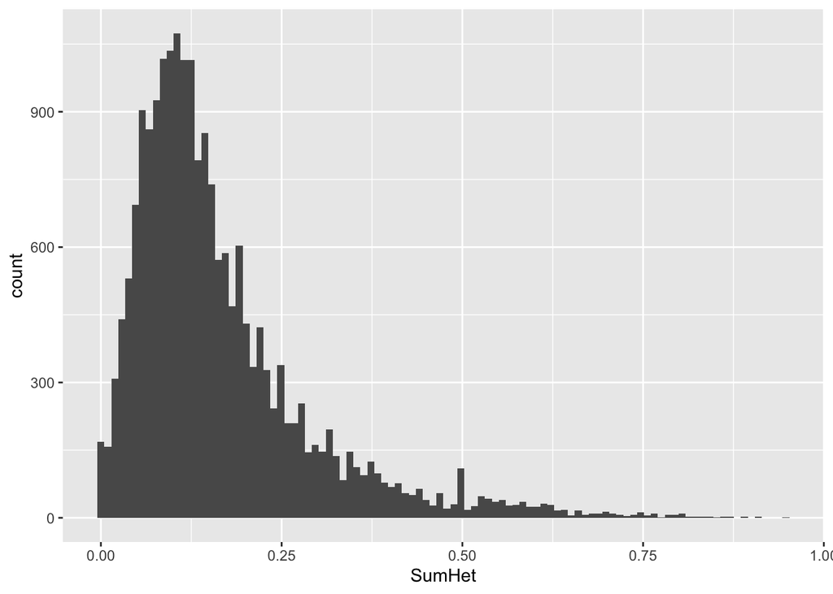

Da es kein spezifischen Rekombinationskoeffizient für BV.BV, es wird direkt dem gesamten Rekombinationskoeffizient angeschaut.

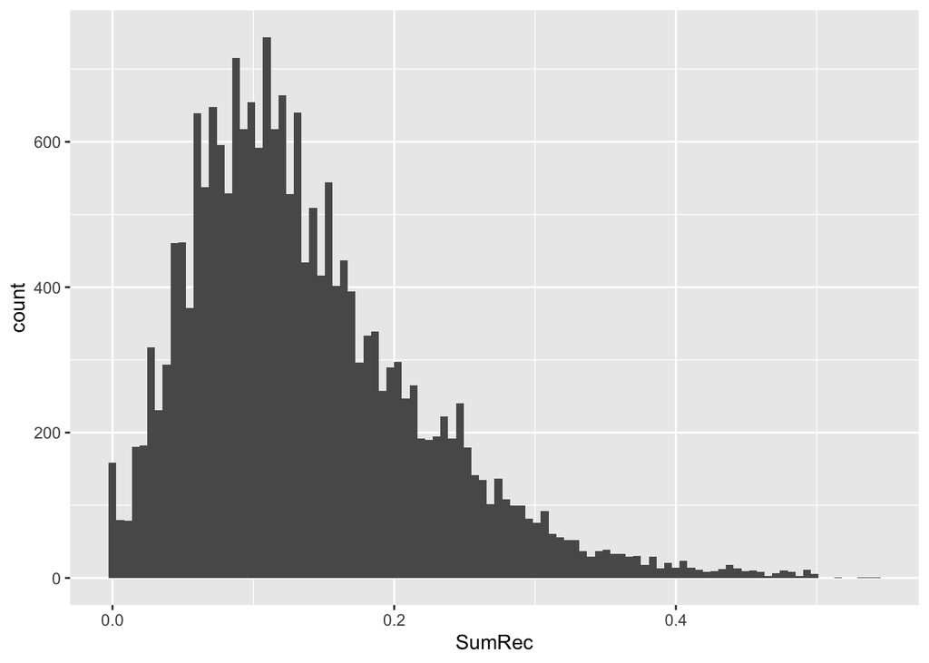

Mit dem gesamten Heterosis wird der Effekt dafür kodiert. Die Varianz von dem wird angeschaut.

```
## # A tibble: 7 x 2
## # Groups:   Effekt_HeterosisSumHet [7]
##   Effekt_HeterosisSumHet     n
##                    <dbl> <int>
## 1                      3 14760
## 2                      4  4162
## 3                      5   903
## 4                      6   241
## 5                      2   151
## 6                      7    33
## 7                      1    20
```

Mit dem gesamten Rekombination wird der Effekt dafür kodiert. Die Varianz von dem wird angeschaut.

```
## # A tibble: 7 x 2
## # Groups:   Effekt_RekombinationSumRec [7]
##   Effekt_RekombinationSumRec     n
##                        <dbl> <int>
## 1                          4  8590
## 2                          3  7446
## 3                          5  3147
## 4                          6   720
## 5                          7   195
## 6                          2   152
## 7                          1    20
```

Es kommt vorwiegend Heterosis/Rekombination zwischen BV/BS mit OB/ROB.

```r
# Get some case to look up
tbl_analyse %>% filter(SxD == "BV.BV" & SumHet != 0) %>% head() %>% select(ind, Effekt_HeterosisSumHet, Effekt_RekombinationSumRec, Het_DPxBR, Rec_DPxBR, SumHet, SumRec)
```

```
## # A tibble: 6 x 7
##   ind     Effekt_Heterosis… Effekt_Rekombinat… Het_DPxBR Rec_DPxBR SumHet SumRec
##   <chr>               <dbl>              <dbl>     <dbl>     <dbl>  <dbl>  <dbl>
## 1 CH1200…                 3                  4     0.144    0.123   0.144 0.123
## 2 CH1200…                 3                  4     0.179    0.147   0.179 0.147
## 3 CH1200…                 4                  4     0.256    0.199   0.256 0.199
## 4 CH1200…                 4                  4     0.25     0.188   0.25  0.188
## 5 CH1200…                 3                  3     0.062    0.0581  0.062 0.0581
## 6 CH1200…                 5                  6     0.423    0.325   0.423 0.325
```

## breedcomb HO.HO

Da es kein spezifischen Heterosiskoeffizient für HO.HO, es wird direkt dem gesamten Heterosiskoeffizient angeschaut.

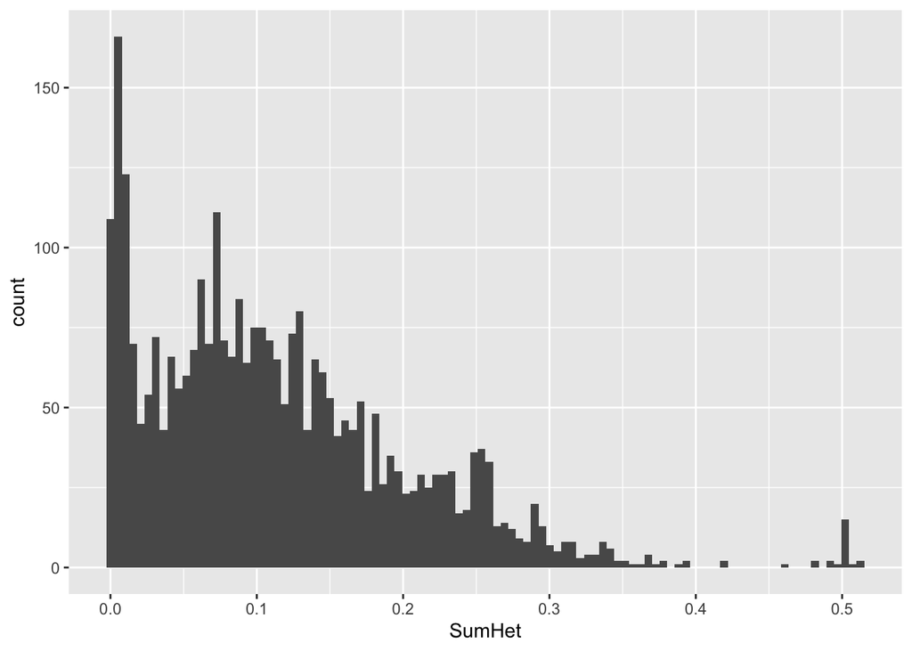

Da es kein spezifischen Rekombinationskoeffizient für HO.HO, es wird direkt dem gesamten Rekombinationskoeffizient angeschaut.

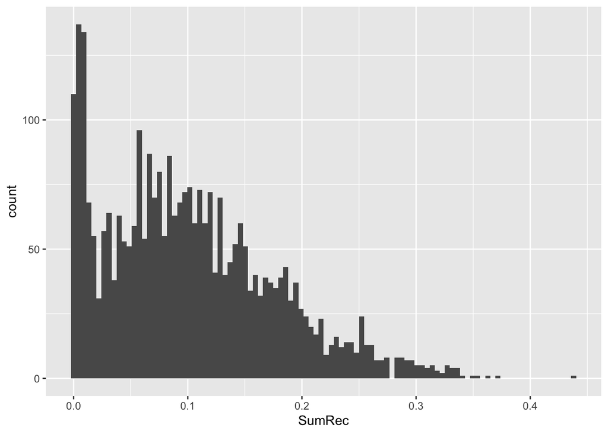

Mit dem gesamten Heterosis wird der Effekt dafür kodiert. Die Varianz von dem wird angeschaut.

```
## # A tibble: 4 x 2
## # Groups:   Effekt_HeterosisSumHet [4]
##   Effekt_HeterosisSumHet     n
##                    <dbl> <int>
## 1                      3  2518
## 2                      4   480
## 3                      2    35
## 4                      5    26
```

Mit dem gesamten Rekombination wird der Effekt dafür kodiert. Die Varianz von dem wird angeschaut.

```
## # A tibble: 6 x 2
## # Groups:   Effekt_RekombinationSumRec [6]
##   Effekt_RekombinationSumRec     n
##                        <dbl> <int>
## 1                          3  1625
## 2                          4  1074
## 3                          5   282
## 4                          6    42
## 5                          2    35
## 6                          7     1
```

```r
# Get some case to look up
tbl_analyse %>% filter(SxD == "HO.HO" & SumHet != 0) %>% select(ind, Het_DPxOS, Het_DPxHO, Rec_DPxHO, Het_OSxHO, Rec_OSxHO, SumHet, SumRec) %>% head()
```

```
## # A tibble: 6 x 8
##   ind            Het_DPxOS Het_DPxHO Rec_DPxHO Het_OSxHO Rec_OSxHO SumHet SumRec
##   <chr>              <dbl>     <dbl>     <dbl>     <dbl>     <dbl>  <dbl>  <dbl>
## 1 CH120003090579    0          0.257    0.253     0          0      0.257 0.253
## 2 CH120003975609    0.0004     0.210    0.166     0.0016     0.002  0.212 0.168
## 3 CH120004468421    0          0.2      0.16      0          0      0.2   0.16
## 4 CH120006311039    0          0.09     0.0819    0          0      0.09  0.0819
## 5 CH120006514454    0          0.113    0.113     0          0      0.113 0.113
## 6 CH120007004992    0          0.336    0.333     0          0      0.336 0.333
```

## breedcomb LM.KR

Da die Mutter-Seite mit “KR” gekennzeichnet ist, werden die spezifische Gruppen (LY, DP, EY, OS, HO, BR) immer mit LM angeschaut. Darunter sind die zwei Gruppe Kombination mit LM wo am meisten Einfluss haben.

Es wird zu dem spezifischen Heterosiskoeffizient von Het_DPxLM angeschaut.

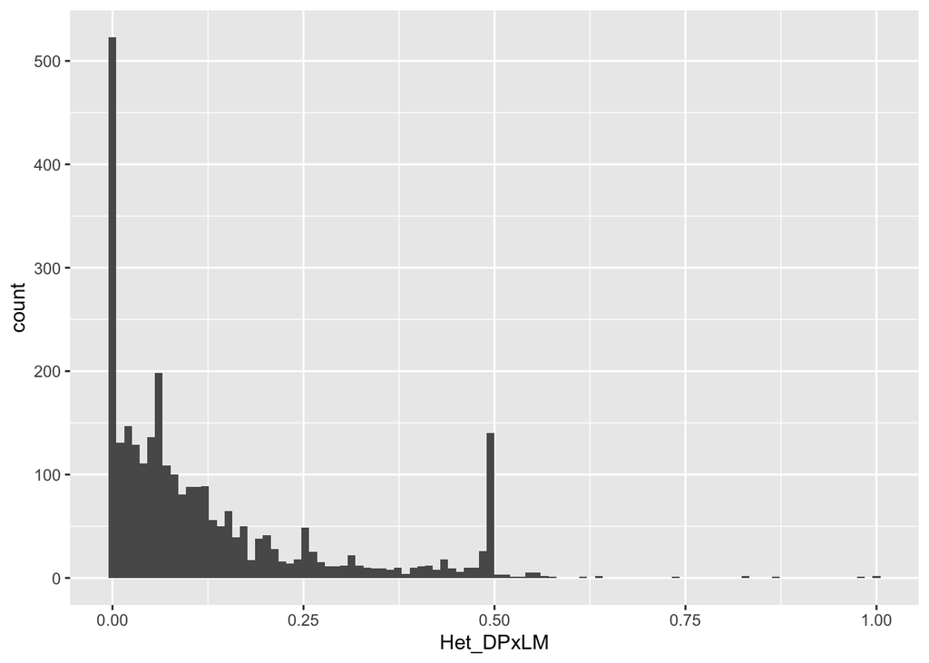

Es wird zu dem spezifischen Heterosiskoeffizient von Het_OSxLM angeschaut.

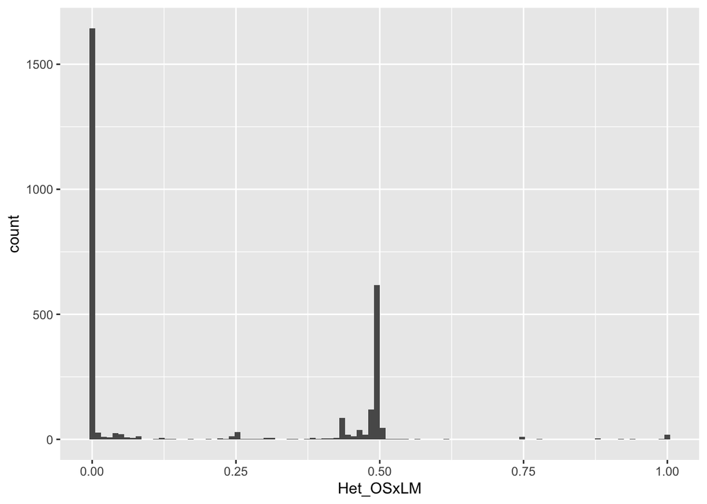

Es wird dem gesamten Heterosiskoeffizient angeschaut

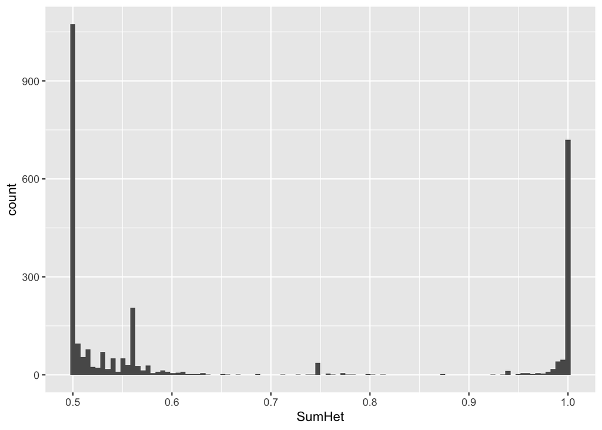

Es wird dem gesamten Rekombinationskoeffizient angeschaut

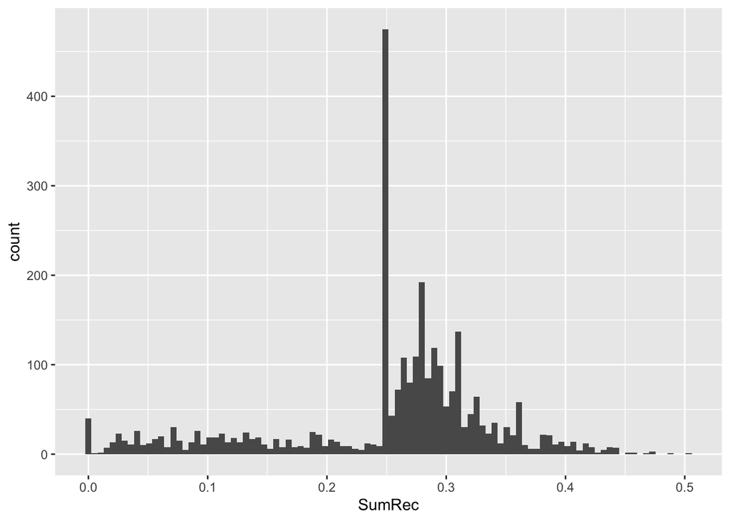

Mit dem gesamten Heterosis wird der Effekt dafür kodiert. Die Varianz von dem wird angeschaut.

```
## # A tibble: 3 x 2
## # Groups:   Effekt_HeterosisSumHet [3]
##   Effekt_HeterosisSumHet     n
##                    <dbl> <int>
## 1                      5  1892
## 2                      7   875
## 3                      6    93
```

Mit dem gesamten Rekombination wird der Effekt dafür kodiert. Die Varianz von dem wird angeschaut.

```
## # A tibble: 6 x 2
## # Groups:   Effekt_RekombinationSumRec [6]
##   Effekt_RekombinationSumRec     n
##                        <dbl> <int>
## 1                          5  1501
## 2                          6   674
## 3                          4   302
## 4                          3   266
## 5                          7    78
## 6                          2    39
```